# Publication Tables

The Data Visualization page covers *when* tables beat graphs (roughly: 20 numbers or fewer, or many localized comparisons) and *how* to design them (sort by values, not alphabetically; shade; round a lot). This page shows how to actually build such tables in R, reproducibly.

```r
library(dplyr)
library(gapminder)

gap2007 <- gapminder %>% filter(year == 2007)
```

## Descriptive tables with `gt`

[`gt`](https://gt.rstudio.com/) is to tables what ggplot2 is to graphs: a grammar. You pipe a data frame in and add layers of formatting.

```r
library(gt)

gap2007 %>%
  group_by(continent) %>%
  summarise(
    Countries = n(),
    `Life Expectancy` = mean(lifeExp),
    `GDP per Capita` = mean(gdpPercap),
    Population = sum(pop)
  ) %>%
  arrange(desc(`Life Expectancy`)) %>%     # sort by values, not alphabet
  gt() %>%
  fmt_number(columns = `Life Expectancy`, decimals = 1) %>%
  fmt_currency(columns = `GDP per Capita`, decimals = 0) %>%
  fmt_number(columns = Population, suffixing = TRUE) %>%  # 1.2B not 1200000000
  data_color(columns = `Life Expectancy`, palette = "viridis") %>%
  tab_header(title = "The World in 2007, by Continent") %>%
  tab_source_note("Data: Gapminder")
```

The World in 2007, by Continent

| continent | Countries | Life Expectancy | GDP per Capita | Population |
| --- | --- | --- | --- | --- |
| Oceania | 2 | 80.7 | $29,810 | 24.55M |
| Europe | 30 | 77.6 | $25,054 | 586.10M |
| Americas | 25 | 73.6 | $11,003 | 898.87M |
| Asia | 33 | 70.7 | $12,473 | 3.81B |
| Africa | 52 | 54.8 | $3,089 | 929.54M |

Data: Gapminder

Note how the design rules from the visualization page appear as code: `arrange()` sorts by the substantively interesting column, `fmt_number(decimals = 1)` rounds a lot, `data_color()` shades cells by value so patterns are visible.

## Regression tables with `modelsummary`

Hand-copying coefficients into Word tables is the leading cause of avoidable errors in submitted papers. [`modelsummary`](https://modelsummary.com/) builds the table straight from the model objects.

```r
library(modelsummary)

m1 <- lm(lifeExp ~ log(gdpPercap), data = gap2007)
m2 <- lm(lifeExp ~ log(gdpPercap) + continent, data = gap2007)

modelsummary(
  list("Bivariate" = m1, "+ Continent" = m2),
  coef_rename = c(
    "log(gdpPercap)" = "Log GDP per Capita",
    "continentAmericas" = "Americas",
    "continentAsia" = "Asia",
    "continentEurope" = "Europe",
    "continentOceania" = "Oceania"
  ),
  gof_map = c("nobs", "r.squared"),
  stars = TRUE,
  notes = "Reference category: Africa. OLS estimates, standard errors in parentheses."
)
```

|  | Bivariate | + Continent |
| --- | --- | --- |
| (Intercept) | 4.950 | 20.138*** |
|  | (3.858) | (4.033) |
| Log GDP per Capita | 7.203*** | 4.631*** |
|  | (0.442) | (0.527) |
| Americas |  | 11.694*** |
|  |  | (1.655) |
| Asia |  | 10.114*** |
|  |  | (1.476) |
| Europe |  | 11.268*** |
|  |  | (1.894) |
| Oceania |  | 12.929** |
|  |  | (4.521) |
| Num.Obs. | 142 | 142 |
| R2 | 0.654 | 0.767 |

+ p < 0.1, * p < 0.05, ** p < 0.01, *** p < 0.001  
Reference category: Africa. OLS estimates, standard errors in parentheses.

`modelsummary()` outputs to HTML, LaTeX, and Word depending on your output format — one code chunk serves the website and the paper. Its sibling `datasummary_skim()` gives a one-line descriptive overview of a whole dataset:

Unique

Missing Pct.

Mean

SD

Min

Median

Max

Histogram

lifeExp

142

0

67.0

12.1

39.6

71.9

82.6

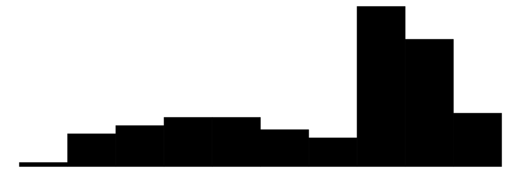

gdpPercap

142

0

11680.1

12859.9

277.6

6124.4

49357.2

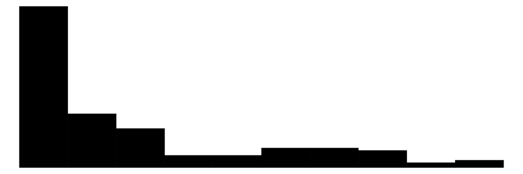

pop

142

0

44021219.6

147621397.9

199579.0

10517531.0

1318683096.0

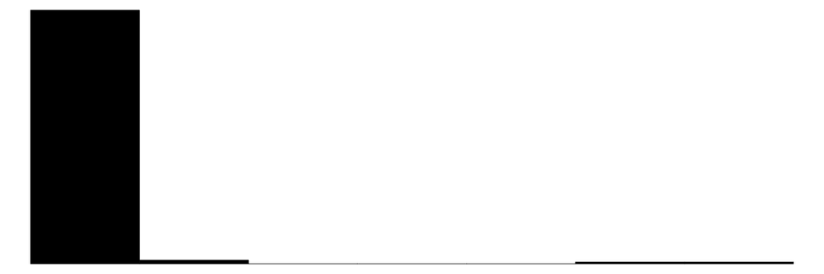

```r
datasummary_skim(gap2007 %>% select(lifeExp, gdpPercap, pop))
```

## Coefficient plot or regression table?

You have both tools now. A useful rule:

- **Table**: when readers need to *look up* exact values (reviewers do), or when you report many models/specifications.
- **Coefficient plot**: when readers should *compare* magnitudes and see which intervals cross zero — presentations, blog posts, and the main text of a paper.

Many papers now do both: plot in the text, full table in the appendix. Since both come from the same model object, this costs you two chunks, not an afternoon.

## Further tools

- [`gtsummary`](https://www.danieldsjoberg.com/gtsummary/) — publication-ready descriptive and regression tables with sensible medical/social-science defaults.
- [`kableExtra`](https://haozhu233.github.io/kableExtra/) — lighter-weight alternative to `gt`, good for PDF output.
- `gt::gtsave()` exports any gt table to .png, .html, .rtf, or .tex.